# HW19

Estimate the (a) coherence time and (b) coherence bandwidth for a cellular phone in a car driving through an urban environment.

The coherence time is given as

$$ t_{coh}=\frac{0.24}{f_{max}} $$

where

$$ f_{max}=\frac{kv}{2\pi}=\frac{v}{\lambda} $$

```python
# part a
v = 40 #mph
v_ms = v * 0.44704 #m/s
f = 845e6 #Hz
lam = 3e8 / f #m
f_max = v / lam #Hz
t_coh = 0.24/f_max #s
print("Coherence Time = ",t_coh, "s")
```

```
Coherence Time =  0.0021301775147928993 s
```

The coherence bandwidth is given by $$BW_{coh}=\frac{1}{t_{coh}}$$

```python
# part b
BW = 1/t_coh #Hz
print("Bandwidth = ",BW, "Hz")
```

```
Bandwidth =  469.44444444444446 Hz
```

For a 1 Ω resistor at temperature T = 290 K connected through an ideal bandpass filter with bandwidth 1 MHz and center frequency 1 GHz to a 1 Ω load, find the (a) RMS value of the noise voltage signal at the load,

Using the noise power the average voltage is calculated as $$ V = \frac{\sqrt{P_n R_{load}}}{2} $$

(b) variance of the signal,

The variance can be found as part of the noise signal which is $$ \sigma_v^2 = N_0 B$$ where $B$ is the bandwidth and $N_0=k_B T$

(c) power spectral density of the signal at the load,

The power spectral density is given as $$S_w(f)=\frac{N_0}{2}$$

(d) autocorrelation function,

The autocorrelation for bandlimited noise is $$ R_w(\tau) = N_0 B \text{sinc}(B\tau)$$ where $\tau=t-s$ is a time delay or time shift

(e) time average power dissipated in the load,

(f) voltage probability distribution function.

It's probably Gaussian since the only power being dissipated is noise power in the absence of a recieved signal.

```python
import numpy as np

# variables
r_source = 1 # ohm
temp = 290 #K
BW = 1e6 #Hz
fc = 1e9 #Hz
r_load = 1 # ohm
k_b = 1.38e-23 #J/K

# part a
Pn = k_b * temp * BW #W
V_RMS_N = np.sqrt(Pn * r_load)/2 #V
print("V_RMS_N = ", V_RMS_N, "V")

# part b
N_0 = k_b * temp #W/Hz
var = N_0 * BW #W
print("Variance = ", var, "W")

# part c
S = N_0 / 2 #W/Hz
print("Spectral Density = ", S, "W/Hz")

# part d
tau = 0.1 #s
R = N_0 * BW * np.sinc(BW*tau) #W
print("Autocorrelation = ", R, "W")

# part e
P_av = V_RMS_N**2 / r_load #W
print("Average Power = ", P_av, "W")
```

```
V_RMS_N =  3.1630681307869426e-08 V
Variance =  4.002000000000001e-15 W
Spectral Density =  2.0010000000000003e-21 W/Hz
Autocorrelation =  -4.326166765697678e-31 W
Average Power =  1.0005000000000002e-15 W
```

3. Derive an expression for the bit error rate for a Rayleigh fading channel.

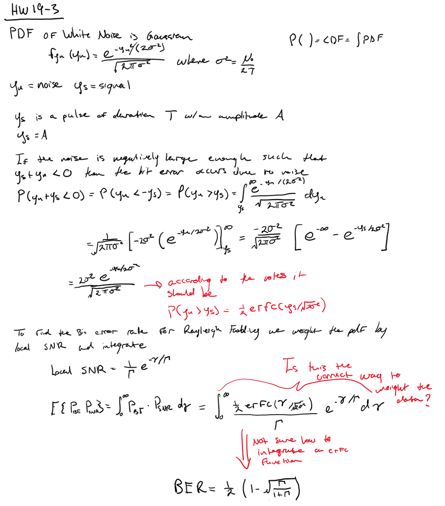

```python
from IPython.display import Image
from IPython.core.display import HTML

# show work done by hand
display(Image("Schw19-3.png", width=500, height=500))
```